# classtpx: Simulation design 1

Kushal K Dey

February 8, 2016

## Classtpx overview

`classtpx` is a R package meant for semi-supervised topic modeling (see [site](https://github.com/kkdey/classtpx)). It is a modification of the `maptpx` package due to Matt Taddy, which performs unsupervised topic models. As a first illustration of the application of the `classtpx` package, we present a simulation example and apply the algorithm on the simulated data. We also compare the results from the `classtpx` application with the `maptpx` method.

```r
library(classtpx)
```

## Simulation Design

```r
n.out <- 200
omega_sim <- rbind( cbind( rep(1, n.out), rep(0, n.out)),
                    cbind( rep(0, n.out), rep(1, n.out)),
                    cbind( seq(0.6, 0.4, length.out = n.out),
                           1- seq(0.6, 0.4,length.out=n.out)) )
dim(omega_sim)
```

```
## [1] 600   2
```

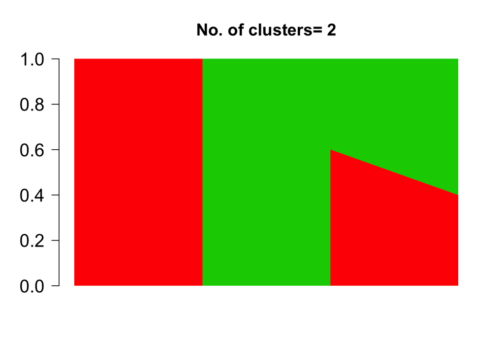

```r
K <- dim(omega_sim)[2]
barplot(t(omega_sim),
        col = 2:(K+1),
        axisnames = F, space = 0,
        border = NA,
        main=paste("No. of clusters=", K),
        las=1, ylim = c(0,1), cex.axis=1.5,cex.main=1.4)
```

We generate the cluster or topic distributions. These are also known as relative gene expression weights of individual cells. Here we simulate $G = 100$ genes, and membership weight

$\begin{pmatrix} q_{,11} & q_{1,2} & \dots & q_{1,G} \\ q_{2,1} & q_{2,2} & \dots & q_{2,G} \end{pmatrix}$

```r
freq <- rbind( c(0.1, 0.2, rep(0.70/98, 98)),
               c(rep(0.70/98,98), 0.1, 0.2) )
str(freq)
```

```
##  num [1:2, 1:100] 0.1 0.00714 0.2 0.00714 0.00714 ...
```

Now we generate the counts table given the topic proportions matrix and the topic distributions.

For every cell $n$, we assume that $C_{n.}$ the vector of read counts coming from genes 1 to G follows a multinomial distribution where $\left( p_{n,1}, \dots, p_{n,G} \right)$ the probabilities of a read coming from genes 1 to $G$ sum up to 1. That is,

$C_{n.} \sim Multinomial \left( C_{n+}, p_{n.} \right)$

and

$p_{n.}= \sum_{k=1}^{K} q_{nk} \theta_{kg}$.

```r
counts <- t( do.call(cbind,
                     lapply(1:dim(omega_sim)[1],
                            function(x)
                                rmultinom(1,1000,prob=omega_sim[x,]%*%freq))))
dim(counts)
```

```
## [1] 600 100
```

## classtpx Application

We assume that we have FACS sorted the cells into two known cell types. Cells numberd $1$ to $100$ are assigend to type 1, and cells $200$ to $300$ are assigned to type 2.

```r
library(classtpx)
known_samples <- c(1:100, 201:300)
class_labs <- c(rep(1,100), rep(2,100))
```

### omega.fix method

```r
Topic_clus <- classtpx::class_topics(
    counts,
    K,
    known_samples = known_samples,
    class_labs = class_labs,
    method="omega.fix",
    tol=0.001)
```

```
##
## Estimating on a 600 document collection.
## log posterior increase: 4019.028, done.
```

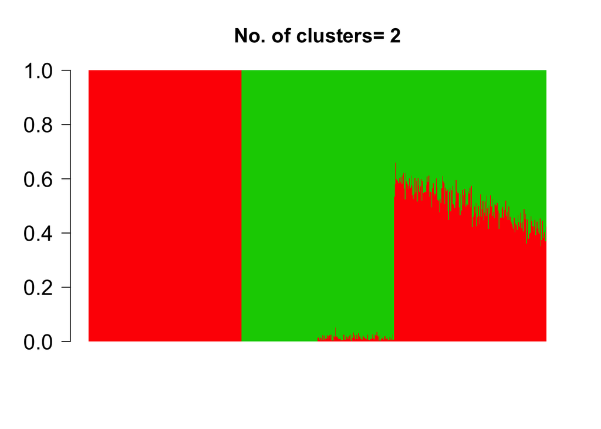

```r
# These are estimated gene relative expression
docweights <- Topic_clus$omega

library(permute)
library(BioPhysConnectoR)

# Decide on the correspondance of the simulated
# and of the estimated relative expression matrix
#
# We consider all possible cluster ordering in the
# estimated relative expression matrix and select
# the relative expression matrix with the nearest
# distance to the simulate relative experssion matrix
# (forbieus norm)

perm_set <- rbind(1:K,allPerms(1:K))
diff <- array(0,dim(perm_set)[1])
for (p in 1:dim(perm_set)[1])
{
    temp <- docweights[, perm_set[p,]]
    diff[p] <- fnorm(temp,omega_sim)
}

p_star <- which(diff==min(diff))
docweights <- docweights[,perm_set[p_star,]]

barplot(t(docweights),
        col = 2:(K+1),
        axisnames = F, space = 0, border = NA,
        main=paste("No. of clusters=", K),
        las=1, ylim=c(0,1), cex.axis=1.5, cex.main=1.4)
```

### theta.fix method

```r
Topic_clus <- classtpx::class_topics(
    counts,
    K,
    known_samples = known_samples,
    class_labs = class_labs,
    method="theta.fix",
    tol=0.001)
```

```
## Due to absence of package REBayes, switching to EM algorithm
```

```
## Due to absence of package REBayes, switching to EM algorithm
```

```
##
## Estimating on a 600 document collection.
## log posterior increase: done.
```

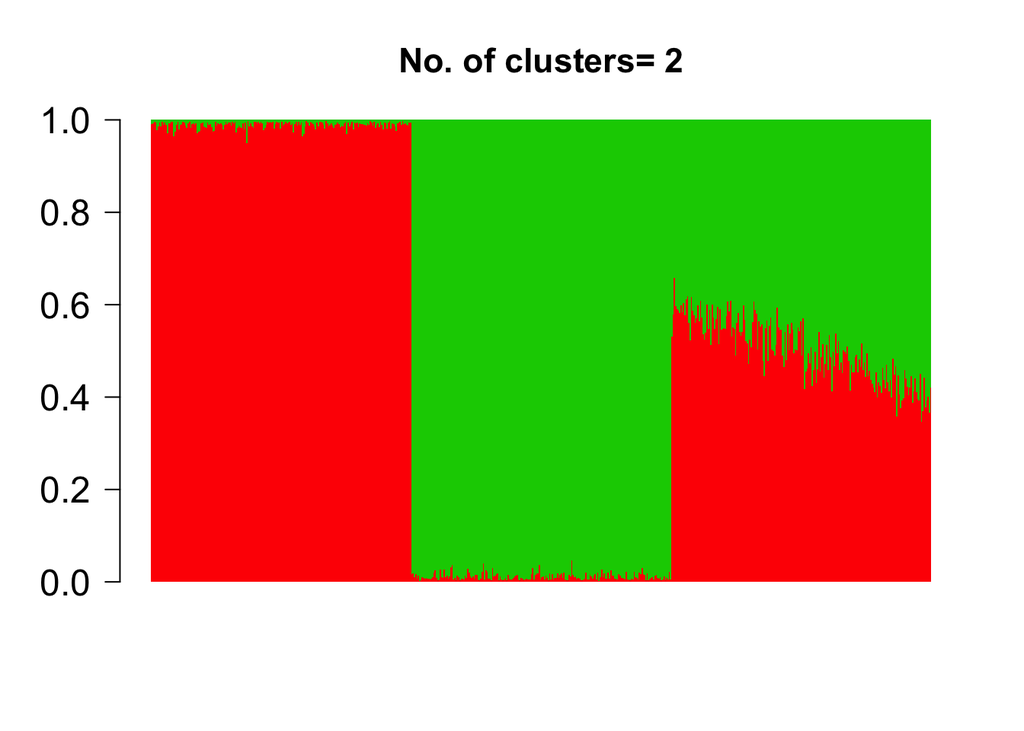

```r
# These are estimated gene relative expression
docweights <- Topic_clus$omega

library(permute)
library(BioPhysConnectoR)

# Decide on the correspondance of the simulated
# and of the estimated relative expression matrix
#
# We consider all possible cluster ordering in the
# estimated relative expression matrix and select
# the relative expression matrix with the nearest
# distance to the simulate relative experssion matrix
# (forbieus norm)

perm_set <- rbind(1:K,allPerms(1:K))
diff <- array(0,dim(perm_set)[1])
for (p in 1:dim(perm_set)[1])
{
    temp <- docweights[, perm_set[p,]]
    diff[p] <- fnorm(temp,omega_sim)
}

p_star <- which(diff==min(diff))
docweights <- docweights[,perm_set[p_star,]]

barplot(t(docweights),
        col = 2:(K+1),
        axisnames = F, space = 0, border = NA,
        main=paste("No. of clusters=", K),
        las=1, ylim=c(0,1), cex.axis=1.5, cex.main=1.4)
```

### theta.prior method

```r
Topic_clus <- classtpx::class_topics(
    counts,
    K,
    known_samples = known_samples,
    class_labs = class_labs,
    method="theta.prior",
    tol=0.001)
```

```
## Due to absence of package REBayes, switching to EM algorithm
## Due to absence of package REBayes, switching to EM algorithm
```

```
##
## Estimating on a 600 document collection.
## log posterior increase: 91.779, 11.65, 0.093, 0.027, 0.009, 0.003, 0.001, done.
```

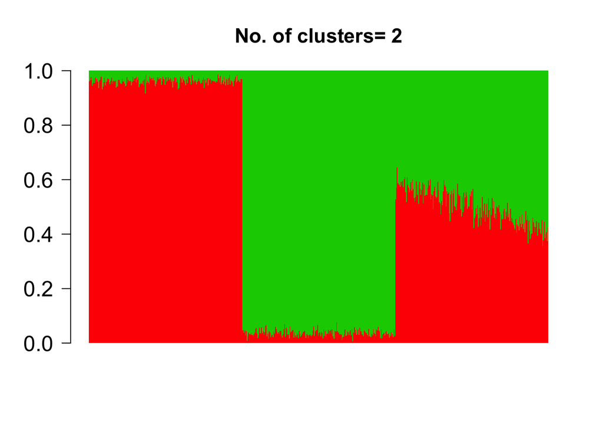

```r
docweights <- Topic_clus$omega;
library(permute);
library(BioPhysConnectoR)
perm_set=rbind(1:K,allPerms(1:K));
diff=array(0,dim(perm_set)[1]);
for (p in 1:dim(perm_set)[1])
{
    temp=docweights[,perm_set[p,]];
    diff[p]=fnorm(temp,omega_sim);
}

p_star=which(diff==min(diff));
docweights=docweights[,perm_set[p_star,]];

barplot(t(docweights),col=2:(K+1),axisnames=F,space=0,border=NA,main=paste("No. of clusters=",K),las=1,ylim=c(0,1),cex.axis=1.5,cex.main=1.4)
```

### no.fix method

```r
Topic_clus <- classtpx::class_topics(
    counts,
    K,
    known_samples = known_samples,
    class_labs = class_labs,
    method="no.fix",
    tol=0.01)
```

```
##
## Estimating on a 600 document collection.
## log posterior increase: 3310.39, 9.72, 0.07, 0.01, done.
```

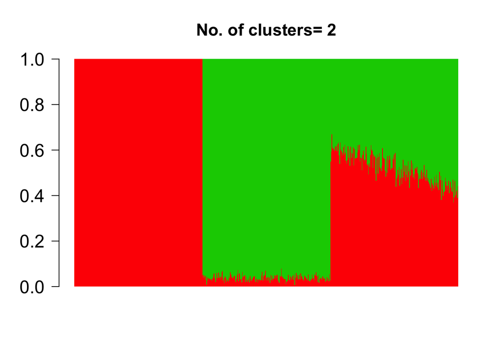

```r
docweights <- Topic_clus$omega;
library(permute);
library(BioPhysConnectoR)
perm_set=rbind(1:K,allPerms(1:K));
diff=array(0,dim(perm_set)[1]);
for (p in 1:dim(perm_set)[1])
{
    temp=docweights[,perm_set[p,]];
    diff[p]=fnorm(temp,omega_sim);
}

p_star=which(diff==min(diff));
docweights=docweights[,perm_set[p_star,]];

barplot(t(docweights),col=2:(K+1),axisnames=F,space=0,border=NA,main=paste("No. of clusters=",K),las=1,ylim=c(0,1),cex.axis=1.5,cex.main=1.4)
```

## maptpx application

```r
Topic_clus <- maptpx::topics(
    counts,
    K,
    tol=0.01)
```

```
##
## Estimating on a 600 document collection.
## Fitting the 2 topic model.
## log posterior increase: 7159.69, 34.69, 0.53, 0.09, 0.02, done.
```

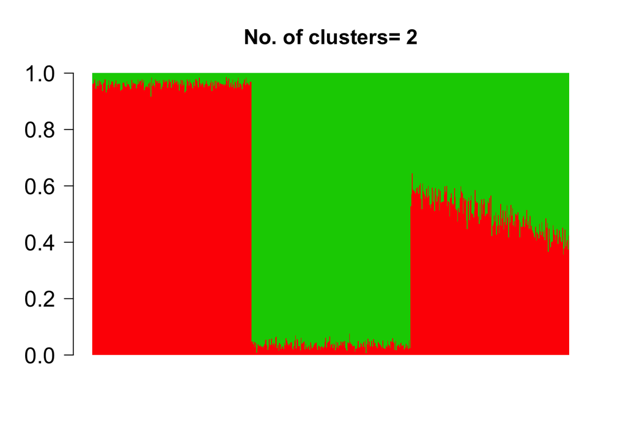

```r
docweights <- Topic_clus$omega;
library(permute);
library(BioPhysConnectoR)
perm_set=rbind(1:K,allPerms(1:K));
diff=array(0,dim(perm_set)[1]);
for (p in 1:dim(perm_set)[1])
{
    temp=docweights[,perm_set[p,]];
    diff[p]=fnorm(temp,omega_sim);
}

p_star=which(diff==min(diff));
docweights=docweights[,perm_set[p_star,]];

barplot(t(docweights),col=2:(K+1),axisnames=F,space=0,border=NA,main=paste("No. of clusters=",K),las=1,ylim=c(0,1),cex.axis=1.5,cex.main=1.4)
```